# LADP

Beichen Su

December 31, 2017

# 1. Introduction

This dataset reflects calls for service incidents in the City of Los Angeles in the year 2014. This data is as accurate as the data in the database. And the link: https://data.lacity.org/A-Safe-City/LAPD-Calls-for-Service-2014/mgue-vbsx.

The specification of the column names are given below:

Incident Number: Unique event number assigned to Calls for Service by dispatch system.

Reporting District: A four-digit code that represents a sub-area within a Geographic Area. All calls for service records reference the “RD” that it occurred in for statistical comparisons. Find LAPD Reporting Districts on the LA City GeoHub at http://geohub.lacity.org/datasets/c4f83909b81d4786aa8ba8

Area Occurred: Area where the occurrence is reported to have been.

Dispatch Date: MM/DD/YYYY

Dispatch Time: In 24 hour military time.

Call Type Code: A code to indicate the type of call that was made.

Call Type Description: Defines the Call Type Code provided.

The incident number can be dropped from the data frame as it’s unique for each call.

The call type code and the call type description can be the same column, so that I keep the code and drop the description. The description can be checked based on the code provided. Same relationship between Reporting District and Area occurred.

# 2. Exploratory analysis

## 2.1 Area occurred

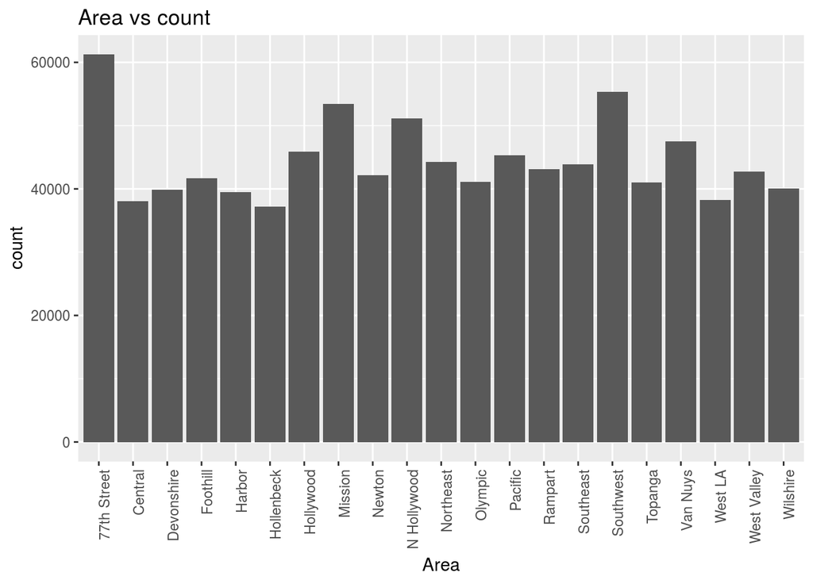

```r
qplot(df$`Area Occurred`, xlab = "Area",main = "Area vs count")+theme(axis.text.x = element_text(angle = 90, hjust = 1))
```

```r
Area <- as.data.frame(table(df$`Area Occurred`))
# Max call area
Area$Var1[which(Area$Freq == max(Area$Freq))]
```

```
## [1] 77th Street
## 21 Levels: 77th Street Central Devonshire Foothill Harbor ... Wilshire
```

```r
# Min call area
Area$Var1[which(Area$Freq == min(Area$Freq))]
```

```
## [1] Hollenbeck
## 21 Levels: 77th Street Central Devonshire Foothill Harbor ... Wilshire
```

```r
# Average call count among all area
mean(Area$Freq)
```

```
## [1] 44418.14
```

## 2.2 Type of call

As there more than 100 kind of call code, the investigation will focus on the top 20 codes.

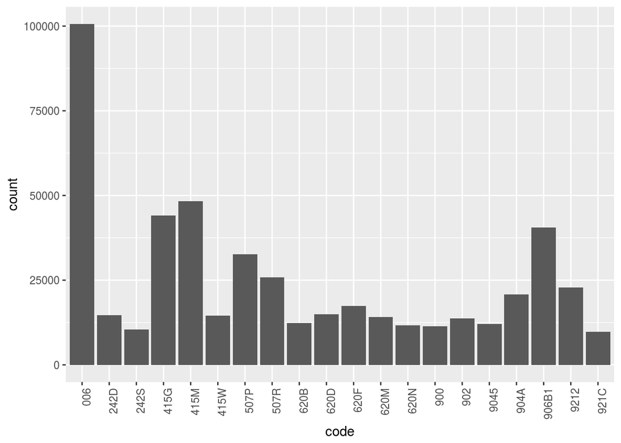

## 2.3 Call Time

The record of date shows that the report were sent uniformly through the year, and a peak at mid July.

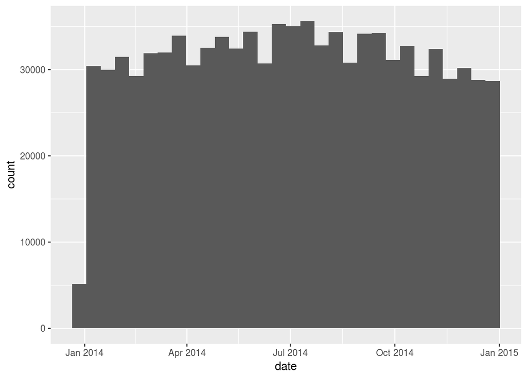

```r
date <- as.Date(df$`Dispatch Date`, format = "%m/%d/%Y")
qplot(date)
```

For the time:

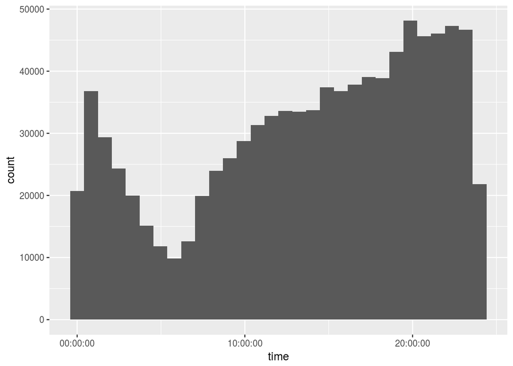

```r
time <- as.difftime(df$`Dispatch Time`)
qplot(time)
```

Most of the report were sent at night. Extremely low call has been received in the morning.

# 3. Model

For all the columns in the dataset, there 3 attributes worth digging: Reporting district, Call type, Date and time. It might be possible to predict the kind of call based on the date, time and district. I will give it a try.

There are more than 900k records in the dataset. I chose 5% of them for the computation capacity on this EC2 machine.

```r
hx <- as.h2o(data)
sp <- h2o.splitFrame(hx,ratios = 0.95)
hx <- sp[[2]]
hx[,1] <- h2o.asfactor(hx[,1])
hx[,2] <- h2o.asfactor(hx[,2])
hx[,3] <- h2o.asfactor(hx[,3])
hx[,4] <- h2o.asfactor(hx[,4])
sp <- h2o.splitFrame(hx,seed = 123)
hx_train <- sp[[1]]
hx_test <- sp[[2]]
cols <- colnames(data)
md <- h2o.randomForest(cols[1:3], cols[4],hx_train, model_id = "First RF", nfolds = 5)
save(md, file = "md.rda")
```

```r
load("md.rda")
md@model$cross_validation_metrics
```

```
## H2OMultinomialMetrics: drf
## ** Reported on cross-validation data. **
## ** 5-fold cross-validation on training data (Metrics computed for combined holdout predictions) **
##
## Cross-Validation Set Metrics:
## =====================
##
## Extract cross-validation frame with `h2o.getFrame("RTMP_sid_be5e_6")`
## MSE: (Extract with `h2o.mse`) 0.9195285
## RMSE: (Extract with `h2o.rmse`) 0.9589205
## Logloss: (Extract with `h2o.logloss`) 20.86441
## Mean Per-Class Error: 0.6369266
## Hit Ratio Table: Extract with `h2o.hit_ratio_table(<model>,xval = TRUE)`
## =======================================================================
## Top-10 Hit Ratios:
##     k hit_ratio
## 1   1  0.079143
## 2   2  0.119000
## 3   3  0.150886
## 4   4  0.175914
## 5   5  0.197371
## 6   6  0.214886
## 7   7  0.228914
## 8   8  0.240914
## 9   9  0.248800
## 10 10  0.254200
```

```r
md@model$cross_validation_metrics_summary
```

```
## Cross-Validation Metrics Summary:
##                                mean           sd cv_1_valid  cv_2_valid
## accuracy                0.079136364 0.0024179395 0.08286898 0.076203965
## err                       0.9208636 0.0024179395   0.917131  0.92379606
## err_count                    6446.0     40.66202     6419.0      6522.0
## logloss                   20.863783   0.21854916  20.498297   21.416906
## max_per_class_error             1.0          0.0        1.0         1.0
## mean_per_class_accuracy  0.55694205 0.0072011068 0.55164087  0.54802316
## mean_per_class_error     0.44305792 0.0072011068 0.44835913   0.4519768
## mse                      0.91953456 0.0012662007 0.91652095  0.92032045
## r2                       0.99998486  1.610669E-7  0.9999846   0.9999848
## rmse                      0.9589232 6.6043646E-4   0.957351   0.9593333
##                          cv_3_valid cv_4_valid cv_5_valid
## accuracy                0.074774384  0.0832154 0.07861909
## err                       0.9252256  0.9167846 0.92138094
## err_count                    6459.0     6478.0     6352.0
## logloss                   20.885157  20.670362  20.848192
## max_per_class_error             1.0        1.0        1.0
## mean_per_class_accuracy   0.5475724  0.5734741  0.5639998
## mean_per_class_error      0.4524276  0.4265259 0.43600023
## mse                       0.9212477   0.918514 0.92106974
## r2                        0.9999846 0.99998516  0.9999851
## rmse                      0.9598165 0.95839137  0.9597238
```

This turns out the prediction on the call type doesn’t really rely on district, date and time. The reason could be that the real reason of the call type is not included in the data, or the training data set should be larger, but I prefer the first reason.